# Práctica 10. Prueba repaso.

Jesús Martín

2024-11-15

### Introducción

En esta práctica vamos a realizar un simulacro en el que estudiemos cómo importar una base de datos, cómo hacer descriptivos básicos y cómo calcular intervalos de confianza de una media y de una proporción. Se articulará en torno a una serie de preguntas y, finalmente habrá que compilar un documento html. El presente documento es la solución a la práctica, que habrá que construir en Rmarkdown

### Ejercicio 1

La primera tarea consiste en importar la base de datos df_prueba.csv. Es importante saber en qué directorio estamos trabajando

```r
getwd ()
```

```
## [1] "C:/Users/jesus.martin/OneDrive - Madrid Digital/Docente/Introducción a la AP/Curso 2024_25/Bioestadística 1/Prácticas/Práctica 10"
```

```r
df_prueba <- read.csv("df_prueba.csv")

head (df_prueba)
```

```
##     fech_nac   sex   alt peso      imc hta fum DM colesterol clas_soc iam1
## 1 1982-08-06 Mujer 152.0 54.0 23.37258  No  No  0        209    Media   No
## 2 1982-09-23 Varón 175.8 88.8 28.73262  No  No  0        185     Baja   No
## 3 1939-03-04 Mujer 155.8 66.8 27.51956  Sí  No  0        184    Media   No
## 4 1936-01-15 Varón 183.3 85.3 25.38774  Sí  No  0        162     Baja   No
## 5 1940-03-23 Varón 168.1 61.1 21.62249  No  No  0        140     Alta   No
## 6 1962-11-10 Mujer 152.8 49.8 21.32960  No  Sí  0        210    Media   Sí
```

### Ejercicio 2

Debes crear la variable edad a partir de la fecha de nacimiento, sabiendo que la fecha de fin de estudio fue el 31/12/2023.

```r
#fech_nac viene definida como character, cambiamos a formato fecha
df_prueba$fech_nac <- as.Date(df_prueba$fech_nac)
fecha_fin <- as.Date("2023-12-31")
df_prueba$edad <- (fecha_fin-df_prueba$fech_nac)/365.25
df_prueba$edad <- as.numeric (round (df_prueba$edad,0))

#Categorizamos imc
df_prueba$imc_r <- cut(df_prueba$imc,
                    breaks = c(-Inf, 20, 30, Inf),
                    labels = c("Bajo", "Normal", "Obesidad"))
```

### Ejercicio 3

Describe las proporciones de hombres y mujeres en cada una de las categorías de la variable `iam1` . Usa las funciones `table`y `prop.table`

```r
#Primero obtenemos las frecuencias absolutas

sex_by_iam <- table(df_prueba$sex, df_prueba$iam1)
sex_by_iam
```

```
##
##          No  Sí
##   Mujer 244  42
##   Varón 211  39
```

```r
#Ahora las proporciones por fila
prop_sex_by_iam <- prop.table(sex_by_iam, margin = 1) * 100
prop_sex_by_iam
```

```
##
##               No       Sí
##   Mujer 85.31469 14.68531
##   Varón 84.40000 15.60000
```

### Ejercicio 4

Describe la variable edad, encuentra su media y su desviación estándar, así como el recorrido intercuartil. Da tu opinión sobre si se puede distribuir como una normal o no.

Puedes usar la función `describe` del paquete `psych`

```r
#install.packages("psych")

library(psych)
#Calcular estadísticas básicas para 'edad'
stats_edad <- describe (df_prueba$edad)

stats_edad
```

```
##    vars   n  mean    sd median trimmed   mad min max range skew kurtosis   se
## X1    1 536 62.65 17.02     63    62.5 22.24  35  93    58 0.05    -1.22 0.74
```

```r
# Calcular la mediana
mediana <- median(df_prueba$edad, na.rm = TRUE)

# Calcular los percentiles 25 y 75
percentiles <- quantile(df_prueba$edad, probs = c(0.25, 0.75), na.rm = TRUE)
q1 <- percentiles[1]  # Percentil 25
q3 <- percentiles[2]  # Percentil 75
# Calcular la amplitud intercuartil
iqr <- IQR(df_prueba$edad, na.rm = TRUE)

# Mostrar resultados
mediana
```

```
## [1] 63
```

```r
iqr
```

```
## [1] 29
```

```r
q1
```

```
## 25%
##  48
```

```r
q3
```

```
## 75%
##  77
```

Para acercarte a decidir si es normal o no la distribución solo con estos datos, puedes ver si la media se sitúa, más o menos en la mitad de la distribución y ver si la mediana está a igual distancia o similar, d elos percentiles 25 y 75. Si esto es así, no puedes descartar que la distribución se asemeje a una normal, pero no puedes asegurarlo. Si no es así, puedes descartarlo.

Después describe la distribución de la variable `edad` en hombres y mujeres utilizando la función `by`

```r
stats_edad_sex <- by(df_prueba$edad, df_prueba$sex, describe)

stats_edad_sex
```

```
## df_prueba$sex: Mujer
##    vars   n  mean    sd median trimmed   mad min max range skew kurtosis   se
## X1    1 286 62.71 16.57   62.5   62.62 20.02  35  93    58 0.04    -1.16 0.98
## ------------------------------------------------------------
## df_prueba$sex: Varón
##    vars   n  mean    sd median trimmed   mad min max range skew kurtosis   se
## X1    1 250 62.58 17.55     63   62.37 22.24  35  93    58 0.05    -1.29 1.11
```

### Ejercicio 5

Haz un histograma con la variable `colesterol`. Después haz un boxplot de la distribución del colesterol en personas sin/con `iam` . Las funciones a utilizar son `hist` y `boxplot` . ¿Te parece que la distribución del colesterol en pacientes sin/con iam pueda asemejarse a una normal? ¿Hay diferencias esperables entre los niveles de colesterol en pacientes sin /con iam?

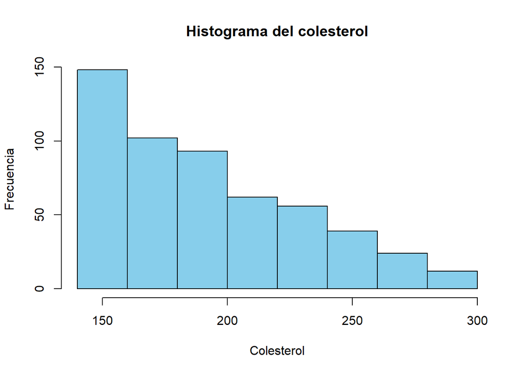

```r
hist(df_prueba$colesterol,
     breaks = 10,
     main = "Histograma del colesterol",
     xlab = "Colesterol",
     ylab = "Frecuencia",
     col = "skyblue")
```

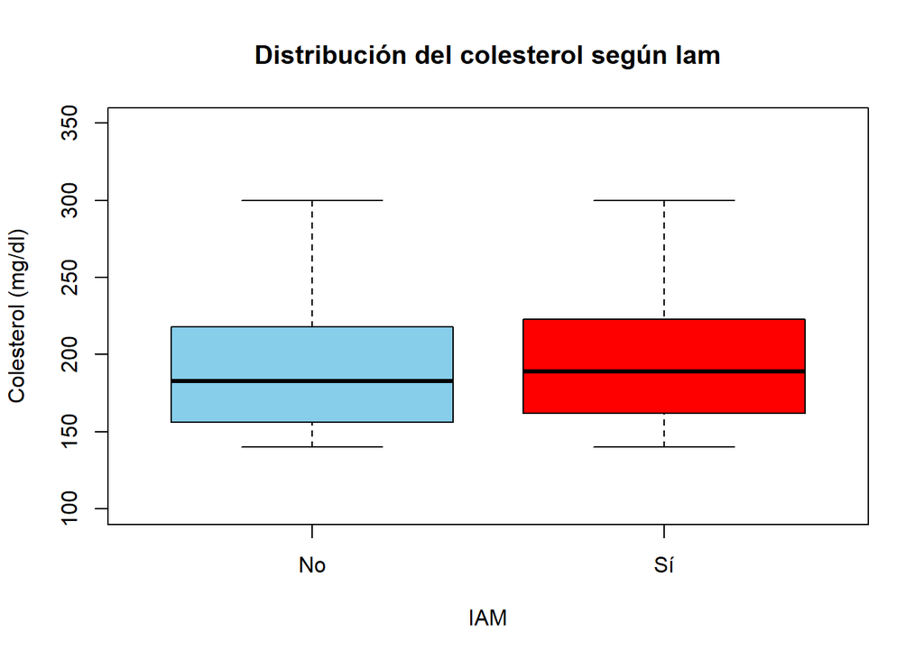

```r
boxplot(df_prueba$col ~ df_prueba$iam1,
main = "Distribución del colesterol según Iam",
xlab = "IAM",
ylab = "Colesterol (mg/dl)",
col = c("skyblue", "red"),
border = c("black", "black"),
ylim = c(100, 350)
)
```

La distribución del colesterol es bastante asimétrica en ambos casos, no parece que se asemeje a una normal y no hay claras diferencias entre los pacientes con/sin IAM

### Ejercicio 6

Explica qué significa ese IC del 95%

```r
#install.packages("Rmisc")

library(Rmisc)
group.CI(imc ~ sex, data = df_prueba, ci = 0.95)
```

```
##     sex imc.upper imc.mean imc.lower
## 1 Mujer  26.57349 26.09270  25.61191
## 2 Varón  27.41641 26.98145  26.54650
```

### Ejercicio 7

Representa gráficamente las estimaciones y los IC del 95% del ejercicio anterior. Usa la función `plotmeans` del paquete `gplots`

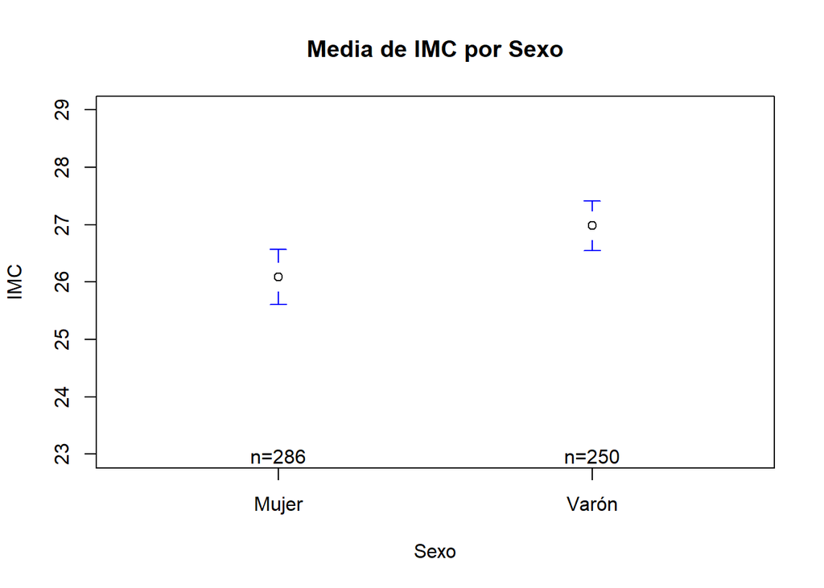

```r
#install.packages("gplots")
library (gplots)
plotmeans(
  imc ~ sex,                     # Fórmula
  data = df_prueba,                # Datos
  ci.label = FALSE,             # No mostrar los IC
  n.label = TRUE,                # Mostrar n de la muestra
  connect = FALSE,               # No conectar las medias
  mean.label = FALSE,           # No mostrar valores de media
  barcol = "blue",               # Color de las barras
  xlab = "Sexo",                 # Etiqueta del eje x
  ylab = "IMC",                 # Etiqueta del eje y
  main = "Media de IMC por Sexo",  # Título
  ylim = c(23, 29),             # Ajustar los límites de y
)
```

### Ejercicio 8

Calcula la proporción de personas que sufren IAM con los métodos de Wilson y Clopper-Pearson (exacto). Instala el paquete `Hmisc` , y entonces puedes usar su función `binconf`

```r
#install.packages("Hmisc")

library(Hmisc)
# Contar las observaciones de "iam" y "No iam"
iam_c <- table(df_prueba$iam1)


# Extraer las proporciones
n_si <-iam_c["Sí"]  # número de "Sí"
n_no <- iam_c["No"]   # número de "No"
n_total <- sum(iam_c)  # total

# Calcular los intervalos de confianza para "Sí" usando el método de Wilson
ci_si <- binconf(n_si, n_total, method = "wilson")

# Calcular los intervalos de confianza para "No" usando el método de Wilson
ci_no <- binconf(n_no, n_total, method = "wilson")



# Calcular los intervalos de confianza para "Sí" usando el método exacto
ci_e_si <- binconf(n_si, n_total, method = "exact")

# Calcular los intervalos de confianza para "No" usando el método exacto
ci_e_no <- binconf(n_no, n_total, method = "exact")



# Mostrar resultados
ci_si
```

```
##   PointEst     Lower     Upper
##  0.1511194 0.1232869 0.1839171
```

```r
ci_no
```

```
##   PointEst     Lower     Upper
##  0.8488806 0.8160829 0.8767131
```

```r
ci_e_si
```

```
##   PointEst    Lower    Upper
##  0.1511194 0.121858 0.184289
```

```r
ci_e_no
```

```
##   PointEst    Lower    Upper
##  0.8488806 0.815711 0.878142
```

### Ejercicio 9

Ahora representa los IC anteriores con la función `plot`

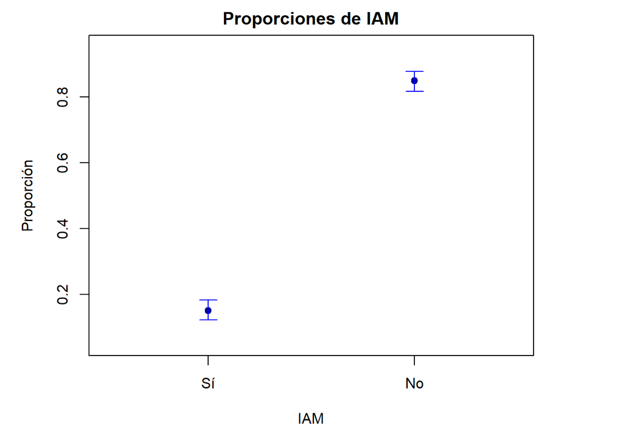

```r
# Calcular el intervalo de confianza para cada categoría
resultado_si <- prop.test(n_si, n_total, correct = FALSE)
resultado_no <- prop.test(n_no, n_total, correct = FALSE)

# Graficar las proporciones con IC
# Ajustar los márgenes del gráfico
par(mar = c(5, 5, 2, 5))
# Aumentar el margen inferior (5) y lateral izquierdo (5)
plot(c(resultado_si$estimate, resultado_no$estimate),
     xaxt = "n",        # Evitar etiquetas automáticas en x
     ylim = c(0.05, 0.95),      # Ajustar el límite de y
     pch = 19,                       # Tipo de punto
     col = "darkblue",               # Color de los puntos
     xlab = "IAM",  # Etiqueta del eje x
     ylab = "Proporción",            # Etiqueta del eje y
     main = "Proporciones de IAM",  # Título
     cex = 1,                        # Tamaño de los puntos
     xlim = c(0.5, 2.5)              # Ajustar límite de eje x
)

# Añadir los nombres de las categorías en el eje x
axis(1, at = 1:2, labels = c("Sí", "No"))

# Añadir los intervalos de confianza para "Sí"
arrows(
  x0 = 1,
  y0 = resultado_si$conf.int[1],
  y1 = resultado_si$conf.int[2],
  angle = 90,
  code = 3,
  length = 0.1,
  col = "blue"
)

# Añadir los intervalos de confianza para "No"
arrows(
  x0 = 2,
  y0 = resultado_no$conf.int[1],
  y1 = resultado_no$conf.int[2],
  angle = 90,
  code = 3,
  length = 0.1,
  col = "blue"
)
```